# Conexión a bases de datos con r

Fernando Pardo

3 de febrero de 2016

## Introducción

En este tema, se explicará cómo se puede utilizar r para conectarse a bases de datos (ya sea remotas o locales), con el fin de obtener datos para nuestros análisis.

Primero que nada, vale la pena hablar un poco de la estructura de una **base de datos relacional**:

1. La información se almacena en tablas, cada una de las cuáles describe objetos bien determinados.
2. Los registros de tablas distintas se enlazan mediante identificadores **id’s**.

En un **esquema de la base de datos**, las tablas se representan por rectángulos, y se enlistan los campos que contienen (con su tipo de datos). Las ligas entre tablas se representan por líneas. Por ejemplo, tenemos la estructura de bases de datos para un blog sencillo:

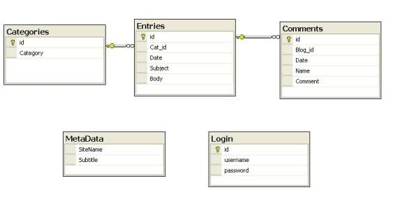

Y las tablas se verían como sigue:

Categories

| id | Category |
| --- | --- |
| 1 | deportes extremos |
| 2 | danza |
| 3 | artes marciales |

Entries

| id | Cat_id | Date | Subject | Body |
| --- | --- | --- | --- | --- |
| 1 | 1 | 15-01-2014 | Tricking | El tricking es… |
| 2 | 1 | 16-02-2015 | Downhill longboarding | Consejos para no morir… |
| 3 | 3 | 20-01-2016 | Kung Fu | El templo Shaolin… |

Comments

| id | Entry_id | Date | Name | Comment |
| --- | --- | --- | --- | --- |
| 1 | 2 | 17-02-2015 | Fernando P. | qué miedo! |

Como se puede observar, cada comentario hace referencia a una entrada del blog, que hace referencia a una categoría.

En la clase de ayer ya vimos cómo lidiar con información organizada de esta manera: usando los joins que vienen en el paquete **dplyr**. Por ejemplo:

```r
library("dplyr")
library("tidyr")

entradas_comentarios <- Entries %>%
  inner_join(Comments, by = c("id" = "Entry_id"))
kable(entradas_comentarios)
```

| id | Cat_id | Date.x | Subject | Body | id.y | Date.y | Name | Comment |
| --- | --- | --- | --- | --- | --- | --- | --- | --- |
| 2 | 1 | 16-02-2015 | Downhill longboarding | Consejos para no morir… | 1 | 17-02-2015 | Fernando P. | qué miedo! |

En realidad, los esquemas de bases de datos reales se ven como el siguiente:

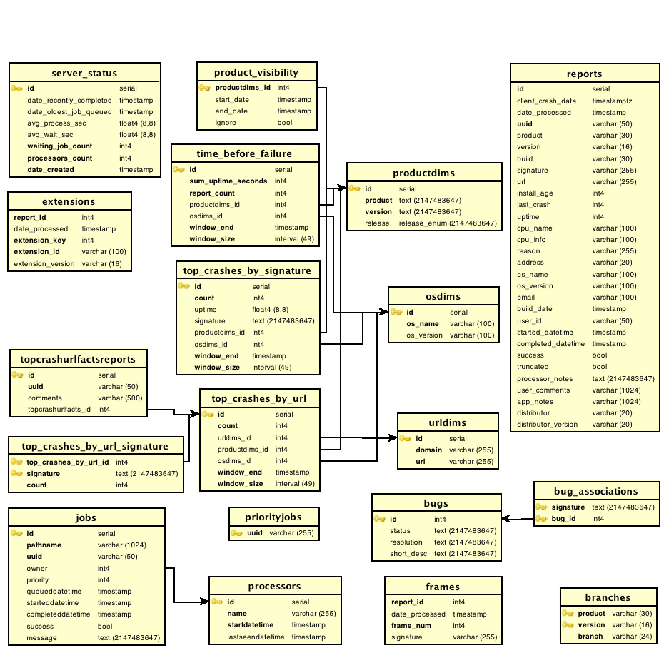

## Conexión a bases de datos SQLite, PostgreSQL y MySQL

Para conectarnos a estas bases de datos, lo más fácil es utilizar el paquete **dplyr**, que incluye las funciones **src_sqlite**, **src_postgres** y **src_mysql**.

Para ejemplificar el uso de dichas funciones, nos conectaremos al SNIB utilizando **src_mysql** (sabemos de antemano que el SNIB es de este tipo de base de datos):

```r
# Obtengo el password del SNIB de mi ambiente local, aunque no es seguridad máxima,
# es mejor que escribirlo y subirlo a internet.
PASS_SNIB <- Sys.getenv("PASS_SNIB")

# Utilizando dplyr me conecto a la base, y la conexión la llamo base_input
snib <- src_mysql(dbname = "geoportal", host = "172.16.1.139", port = 3306,
   user = "lectura", password = PASS_SNIB)

# Obteniendo la lista de tablas de la base de datos:
src_tbls(snib)
```

```
## [1] "InformacionGeoportal"
```

Los parámetros de la función **src_mysql** son los siguientes, y se debe preguntar por sus valores a los encargados de la administración de la base de datos:

- **dbname**: nombre de la base de datos
- **host**: dirección del servidor de la base de datos
- **port**: puerto de acceso a la base de datos
- **user**: usuario (debe estar registrado en la base)
- **password**

Una vez que obtuvimos acceso a la base, podemos hacerle **queries (consultas)** y obtener datos. Las consultas se realizan a una o varias **tablas (tbl)**, **seleccionando (select)** campos de interés y **filtrando (filter)** registros de acuerdo a criterios deseados.

Por ejemplo:

```r
# para obtener una tabla, usamos la función tbl, que acepta la conexión a la base
#de datos, y el nombre de la tabla.

datos_snib_ejemplo <- tbl(snib, "InformacionGeoportal") %>%
  head() %>%
  collect()

# Visualizando los datos
glimpse(datos_snib_ejemplo)
```

```
## Observations: 6
## Variables: 74
## $ idejemplar                     (chr) "92d393a61e10a943547da97c59e515...
## $ region                         (chr) "MEXICO / CHIAPAS / OCOZOCOAUTL...
## $ localidad                      (chr) "Rancho El Aguajito, Reserva Ec...
## $ longitud                       (dbl) -93.6417, -93.6417, -93.6417, -...
## $ latitud                        (dbl) 16.9083, 16.9083, 16.9083, 16.9...
## $ datum                          (chr) "", "", "", "", "", ""
## $ geovalidacion                  (chr) "V\xe1lido municipios 2010", "V...
## $ paismapa                       (chr) "MEXICO", "MEXICO", "MEXICO", "...
## $ estadomapa                     (chr) "CHIAPAS", "CHIAPAS", "CHIAPAS"...
## $ municipiomapa                  (chr) "OCOZOCOAUTLA DE ESPINOSA", "OC...
## $ incertidumbreXY                (int) NA, NA, NA, NA, NA, NA
## $ altitudmapa                    (int) 702, 702, 702, 702, 702, 700
## $ usvserieI                      (chr) "SELVA ALTA PERENNIFOLIA", "SEL...
```

[output cut: 61 more lines]

```r
datos_snib_38 <- tbl(snib, "InformacionGeoportal") %>%
  filter(proyecto == "038") %>%
  select(
    longitud,
    latitud,
    fecha = fechacolecta,
    especie = especievalidabusqueda) %>%
# al final usamos collect para obtener los datos (mientras no lo hagamos, los datos
# no se obtienen: lazy evaluation)
  collect()

# Visualizando los datos
glimpse(datos_snib_38)
```

```
## Observations: 2,064
## Variables: 4
## $ longitud (dbl) -93.6417, -93.6417, -93.6417, -93.6417, -93.6417, -93...
## $ latitud  (dbl) 16.9083, 16.9083, 16.9083, 16.9083, 16.9083, 16.9167,...
## $ fecha    (chr) "1991-10-03", "1991-10-03", "1991-10-03", "1991-10-05...
## $ especie  (chr) "Lepidophyma lipetzi", "Ninia diademata", "", "Scelop...
```

Cabe destacar que los datos recién obtenidos deben ser limpiados (recordar la clase pasada), antes de jugar con ellos:

```r
# Creando nuestra matriz de sitios por géneros, sabemos que no encaja muy bien
# dentro de la definición de datos limpios, pero es muy utilizada en ecología.
datos_snib_sitios_generos <- datos_snib_38 %>%
  filter(!is.na(latitud), !is.na(longitud), !is.na(especie), especie != "") %>%
  separate(especie, c("genero", "especie")) %>%
  group_by(genero, latitud, longitud) %>%
    summarize(
      abundancia = n()
    ) %>%
  spread(genero, abundancia, fill = 0)

# Viendo una subtabla de la anterior
kable(datos_snib_sitios_generos[1:5,1:10])
```

| latitud | longitud | Abronia | Adelphicos | Agalychnis | Amastridium | Anolis | Aspidoscelis | Atropoides | Basiliscus |
| --- | --- | --- | --- | --- | --- | --- | --- | --- | --- |
| 15.2222 | -92.4167 | 0 | 0 | 0 | 0 | 0 | 0 | 0 | 0 |
| 15.2403 | -92.4722 | 1 | 0 | 0 | 0 | 0 | 0 | 0 | 0 |
| 15.4678 | -92.8492 | 0 | 0 | 0 | 0 | 1 | 0 | 0 | 0 |
| 15.4761 | -92.8453 | 0 | 0 | 0 | 0 | 0 | 0 | 0 | 0 |
| 15.4767 | -92.8475 | 0 | 0 | 0 | 0 | 2 | 0 | 0 | 0 |

Finalmente, conectarse a una base postgres es muy parecido (si no es que igual, a conectarse a una base mysql). Conectarse a una base sqlite sólo requiere saber el path hacia ella (pues una base sqlite es un archivo local).

**Ejercicio:** haz algunos queries interesantes a la base de datos del SNIB, por ejemplo, obtén información acerca de algunas especies que te interesen.

## Conexión a una base de datos SQL Server u Oracle

Para conectarnos a estas bases de datos, se necesita utilizar otro paquete. Aquí lo ejemplificaremos con **RJDBC**.

### Instalación de RJDBC

Se necesita hacer una configuración previa para utilizar este paquete con una base de datos SQL Server.

1. Descargar el driver de SQL Server [aquí:](http://www.microsoft.com/en-us/download/details.aspx?displaylang=en&id=11774). Descargar el archivo **sqljdbc_6.0.6629.101_enu.exe** (Windows), o el **sqljdbc_6.0.6629.101_enu.tar.gz** (Mac OS/Linux).
2. - Para Windows, correr el ejecutable. Apuntar de la ruta donde se encuentra el archivo *jar*, porque será necesaria posteriormente.
   - Para Mac, abrir la terminal, mover el archivo a *home del usuario*, abrir la terminal y correr el comando: *tar -xf nombre_del_archivo*.

**Nota:** Si a la hora de cargar el paquete **RJDBC** en nuestra sesión de R, sale un error, es muy probable que se tenga que instalar **Java**. Para descargarlo, hacer click [aquí](https://www.java.com/es/download/)

### Conexión a una base de datos con RJDBC

La información que se requiere para hacer la conexión es muy parecida a la de dplyr (dirección del servidor, puerto, base de datos, usuario, etc…). Sin embargo, el proceso de conexión es un poco más complicado:

```r
library("RJDBC")
# Conexión a la base de datos con RJDBC:

# 1. Creo un objeto tipo Driver (paso adicional). En classPath debemos poner la
# ruta donde se encuentra el archivo sqljdbc4.jar que se encuentra en la carpeta
# que acabamos de descargar.
drv <- JDBC(driverClass = "com.microsoft.sqlserver.jdbc.SQLServerDriver",
  classPath = "auxiliar/sqljdbc4.jar", identifier.quote="`")

# 2. Obtengo el password del INFyS
PASS_INFYS = Sys.getenv("PASS_INFYS")

# 3. Me conecto con la información provista por el administrador de la base de datos.
infys <- dbConnect(drv,
  "jdbc:sqlserver://172.16.1.165;databaseName=INFyS_2009_2012",
  port = 49354, user = "fpardo", password = PASS_INFYS)

# Obteniendo los nombres de las tablas de la base de datos
dbGetTables(infys)[,c("TABLE_SCHEM", "TABLE_NAME")]
```

```
##            TABLE_SCHEM                                     TABLE_NAME
## 1                  dbo                                  CatAbundancia
## 2                  dbo                               CatAccesibilidad
## 3                  dbo                                 CatAgenteDanio
## 4                  dbo                                 CatAgentePlaga
## 5                  dbo                              CatAniosIncendios
## 6                  dbo                                  CatBrigadista
## 7                  dbo                       CatBrigadista_Incompleto
## 8                  dbo                                    CatCarta150
## 9                  dbo                  CatCategoriaSueloXProfundidad
## 10                 dbo                                CatCausaImpacto
## 11                 dbo                               CatCoberturaXVeg
## 12                 dbo                                   CatCondicion
## 13                 dbo                                  CatCuerpoAgua
## 14                 dbo                                       CatDanio
```

[output cut: 490 more lines]

En el proceso anterior:

Primero creé un objeto del tipo driver, que contiene la información acerca de cómo establecer la conexión con una base de datos SQL Server (en este caso). Ésto se logra con la función **JDBC**, del paquete **RJDBC**.

En el segundo paso me conecto a la base de datos deseada, utilizando la función **dbConnect**. Primero le paso el driver y luego las credenciales.

Ya que me conecté al INFyS, puedo obtener los datos, en este caso se utilizan otra función distinta a **tbl()** puesto que no estamos usando dplyr para conectarnos a la base de datos. Cabe destacar que tampoco necesitamos usar ninguna función que juegue el papel de **collect()**:

```r
conglomerados <- dbReadTable(infys, "dbo.TblConglomerado")
class(conglomerados)
```

```
## [1] "data.frame"
```

```r
glimpse(conglomerados)
```

```
## Observations: 17,982
## Variables: 52
## $ IdConglomerado              (dbl) 54, 60, 62, 64, 66, 104, 138, 139,...
## $ Anio                        (dbl) 2009, 2010, 2012, 2009, 2011, 2012...
## $ IdCoordenadaSitio1          (dbl) NA, NA, 0, NA, 0, 0, 0, 0, NA, NA,...
## $ TipoFormato                 (dbl) 3, 3, 3, 3, 3, 3, 3, 1, 3, 3, 3, 3...
## $ Fecha                       (chr) "2009-09-11 00:00:00.0", "2010-07-...
## $ TipoConglomerado            (dbl) 1, 1, 1, 1, 1, 1, 2, 1, 1, 1, 1, 1...
## $ Estado                      (dbl) 2, 2, 2, 2, 2, 2, 2, 2, 2, 2, 2, 2...
## $ Municipio                   (chr) "02003", "02003", "02003", "02003"...
## $ Predio                      (chr) "Rancho El Carrizo", "Ejido Felipe...
## $ Tenencia                    (dbl) 3, 1, 1, 1, 4, 3, 1, 3, 3, 3, 3, 1...
## $ CveCartaInegi               (chr) "I11D72", "I11D62", "I11D63", "I11...
## $ CveFotoAerea                (chr) "\\Archivos\\54\\Fotos\\54_3_0_090...
## $ Cuenca                      (chr) "B.C.  Noroeste", "B.C.  Noroeste"...
```

[output cut: 39 more lines]

```r
estados <- dbReadTable(infys, "dbo.CatEstado")
colnames(estados)
```

```
## [1] "CveEstado" "NomEstado"
```

```r
head(estados)
```

```
##   CveEstado           NomEstado
## 1         1      Aguascalientes
## 2         2     Baja California
## 3         3 Baja California Sur
## 4         4            Campeche
## 5         5            Coahuila
## 6         6              Colima
```

Como los datos ya los tenemos en formato data frame de R, podemos utilizarlos para hacer nuestros análisis, usando todo lo que hemos aprendido con anterioridad.

```r
conglomerados_estados_id <- conglomerados %>%
  select(
    IdConglomerado,
    Estado
  )
head(conglomerados_estados_id)
```

```
##   IdConglomerado Estado
## 1             54      2
## 2             60      2
## 3             62      2
## 4             64      2
## 5             66      2
## 6            104      2
```

```r
# Por ejemplo, haciendo el join de conglomerados con estados para cambiar el id de
# estado por el nombre:
conglomerados_estados <- conglomerados_estados_id %>%
  inner_join(estados, by = c("Estado" = "CveEstado"))
head(conglomerados_estados)
```

```
##   IdConglomerado Estado       NomEstado
## 1             54      2 Baja California
## 2             60      2 Baja California
## 3             62      2 Baja California
## 4             64      2 Baja California
## 5             66      2 Baja California
## 6            104      2 Baja California
```

Para conectarnos a bases de datos Access, se puede utilizar el paquete [RODBC](https://cran.r-project.org/web/packages/RODBC/index.html). Un tutorial útil se puede encontrar [aquí](http://rprogramming.net/connect-to-ms-access-in-r/).